# 11.4 PCA and the Autoencoder

code

share

► [Chapter 11: Linear unsupervised learning](https://jermwatt.github.io/mlrefined/index.html)  
11.4 PCA and the Autoencoder

## 11.2.5 PCA and the Autoencoder

To begin, note that we can restrict ourselves to only orthonormal bases by constraining the Least Squares cost function in equation (27) so that $\mathbf{C}^T\mathbf{C}^{\,} = \mathbf{I}_{N\times N}$, and we can express this adjustment formally by adding the constraint to equation (28) as

\begin{equation} \begin{aligned} \underset{\mathbf{w}_1,\mathbf{w}_2,...,\mathbf{w}_P,\mathbf{C}}{\,\,\,\,\,\mbox{minimize}\,\,\,} & \,\,\,\, \frac{1}{P}\sum_{p = 1}^P \left \Vert \mathbf{C}\mathbf{w}_p - \mathbf{x}_p \right\Vert_2^2 \\ \mbox{subject to}\,\,\, & \,\,\,\,\, \mathbf{C}^T\mathbf{C}^{\,} = \mathbf{I}_{N\times N}. \,\,\,\,\,\, \end{aligned} \end{equation}

As we will see by studying this constrained problem, we can but need not use a formal iterative method (e.g., coordinate descent, gradient descent) to solve the above problem.

So suppose we enforce the orthonormal constraint - what happens to our cost function? Immediately we can say - from either equation (29) or its precursor in Section 1.1 equation (15) - that irregardless of the actual value of $\mathbf{C}$ the formula for an ideal set weights for our basis will always be given by the compact / formula

\begin{equation} \mathbf{w}_p = \mathbf{C}^T\mathbf{x}_p \,\,\,\,\,\,\,\,\,\,\,\,\,\,\,\,\,\,\,\,\,\,\,\, p=1...P . \end{equation}

Previous in Section 1 we emphasized the benefit of this update - it is far more computationally efficient than solving linear systems (which we must do when the basis is not orthonormal). Here since we are learning $\mathbf{C}$ (as opposed to it being fixed) this benefit is magnified: *the constraint that our basis must be orthonormal makes our weight vectors completely redundant*. In other words, replacing the weight vectors in our cost function in equation (7) with the updates given above our cost function becomes

\begin{equation} g\left(\mathbf{C}\right) = \frac{1}{P}\sum_{p = 1}^P \left \Vert \mathbf{C}_{\,}^{\,}\mathbf{C}_{\,}^T\mathbf{x}_p - \mathbf{x}_p \right\Vert_2^2 \end{equation}

which is a function of $\mathbf{C}$ alone.

Let us briefly examine one summand of this reduced cost function. Expanding the of the $p^{th}$ summand and using our assumption that $\mathbf{C}^T\mathbf{C}^{\,} = \mathbf{I}_{N\times N}$ we can see that it may be re-written equivalently as

\begin{equation} \left \Vert \mathbf{C}_{\,}\mathbf{C}^T\mathbf{x}_p - \mathbf{x}_p \right\Vert_2^2 = -\left\Vert \mathbf{C}^T\mathbf{x}_p \right\Vert_2^2 + \left \Vert\mathbf{x}_p\right \Vert_2^2. \end{equation}

# PCA linear version as regression

\begin{equation} g\left(\mathbf{C}\right) = \frac{1}{P}\sum_{p = 1}^P \left \Vert \mathbf{C}_{\,}^{\,}\mathbf{C}_{\,}^T\mathbf{x}_p - \mathbf{x}_p \right\Vert_2^2 \end{equation}

Technically speaking $\mathbf{C}^T\mathbf{C} = \mathbf{I}_{N\times N}$. Lets drag out the main pieces.

```python
x = np.loadtxt(datapath + '2d_span_data.csv',delimiter=',')
```

```python
def standard_normalizer(x):
    # compute the mean and standard deviation of the input
    x_means = np.mean(x,axis = 1)[:,np.newaxis]
    # x_stds = np.std(x,axis = 1)[:,np.newaxis]

    # create standard normalizer function based on input data statistics
    normalizer = lambda data: (data - x_means) #/x_stds

    # return normalizer and inverse_normalizer
    return normalizer
```

```python
# return normalization functions based on input x
normalizer = standard_normalizer(x)

# normalize input by subtracting off mean and dividing by standard deviation
x = normalizer(x)
```

```python
def encoder(x,w):
    return np.dot(w.T,x)
def decoder(w,v):
    return np.dot(w,v)
```

```python
# compute linear combination of input point
def model(x,w):
    # perform encoding
    v = encoder(x,w)

    # perform decoding
    a = decoder(w,v)
    return a
```

```python
# an implementation of the least squares cost function for linear regression
def PCA_least_squares(w):
    cost = np.sum((model(x,w) - x)**2)
    return cost/float(x.shape[1])
```

#### Example 1. Full linear PCA via regression

```python
best_weights = []
num_runs = 3
for i in range(num_runs):
    # tune pca least squares cost
    g = PCA_least_squares; alpha_choice = 10**(-2); max_its = 1000; w = 0.1*np.random.randn(2,2);
    weight_history_1,cost_history_1 = optimizers.gradient_descent(g,alpha_choice,max_its,w)

    # pluck out best weights
    ind = np.argmin(cost_history_1)
    w_best = weight_history_1[ind]
    best_weights.append(w_best)
```

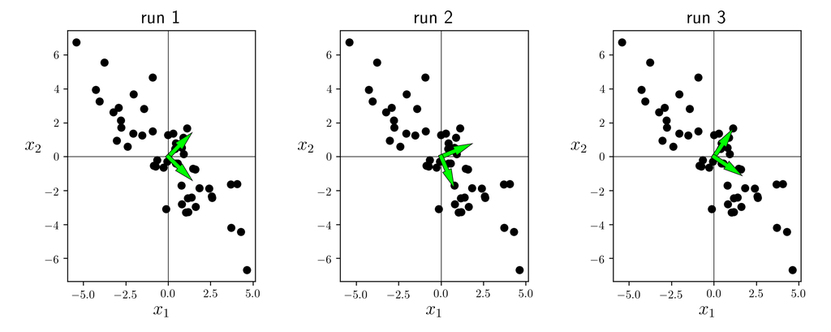

```python
unlib.autoencoder_demos.visual_comparison(x,best_weights)
```

#### Example 2. Partial linear PCA via regression

```python
# tune pca least squares cost
g = PCA_least_squares; alpha_choice = 3*10**(-4); max_its = 300; w = 0.1*np.random.randn(2,1);
w = np.array([-4.5,4.5])[:,np.newaxis]
weight_history_1,cost_history_1 = optimizers.gradient_descent(g,alpha_choice,max_its,w)
```

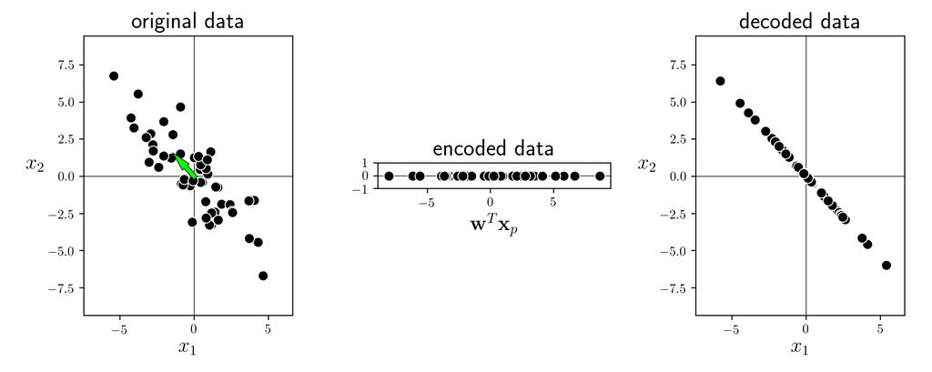

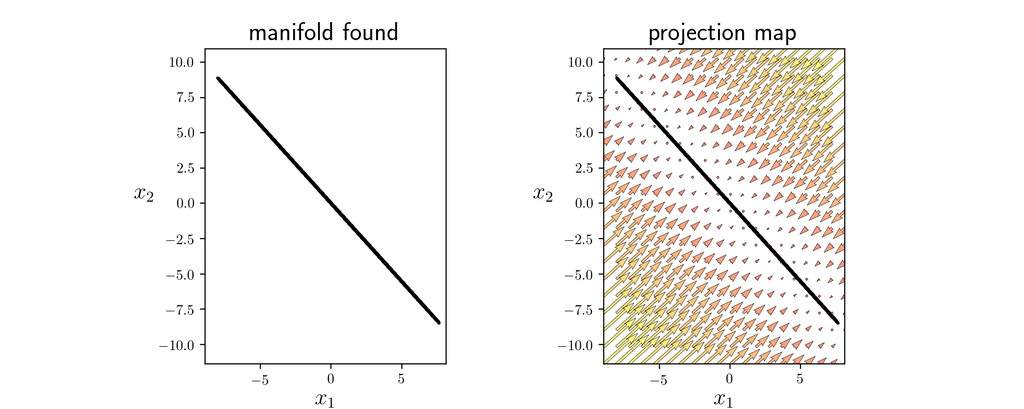

```python
unlib.autoencoder_demos.show_encode_decode(x,encoder,decoder,cost_history_1,weight_history_1,show_pc = True,scale = 150,encode_label = r'$\mathbf{w}^T\mathbf{x}_p$')
```

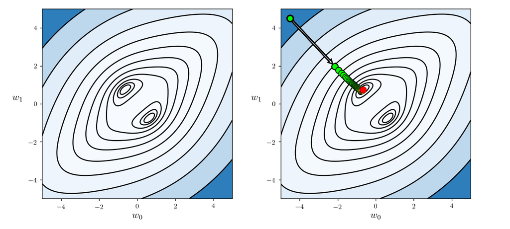

```python
# show run on contour plot
static_plotter.two_input_contour_plot(PCA_least_squares,weight_history_1,xmin = -5,xmax = 5,ymin = -5,ymax = 5,num_contours = 11,show_original = True)
```

#### Example 1. Circular case

```python
x = np.loadtxt(datapath + 'circle_data.csv',delimiter=',')
```

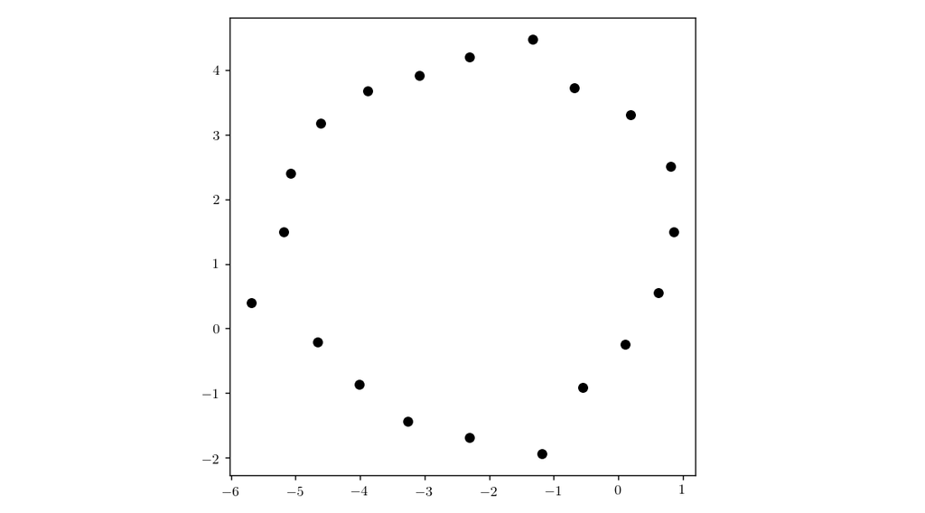

```python
# # # create dataset
# num_pts = 21
# thetas = np.linspace(0,2*np.pi,num_pts)
# # thetas = 2*np.pi*np.random.rand(1,num_pts)
# noise = 0.25*np.random.randn(1,num_pts)
# radius = 3.1
# noise += radius
# x1 = noise*np.cos(thetas)[np.newaxis,:] - 2.3
# x2 = noise*np.sin(thetas)[np.newaxis,:] + 1.5

# x = np.vstack((x1,x2))
# x = x[:,:-1]

fig = plt.figure(figsize = (9,5))
gs = gridspec.GridSpec(1,1)
ax1 = plt.subplot(gs[0],aspect = 'equal');
ax1.scatter(x[0,:],x[1,:],c = 'k',s = 60,linewidth = 0.75,edgecolor = 'w')
```

```python
# an implementation of the least squares cost function for linear regression
def PCA_least_squares(w):
    cost = np.sum((model(x,w) - x)**2)
    return cost/float(x.shape[1])
```

```python
# compute linear combination of input point
def model(x,w):
    # perform encoding
    v = encoder(x,w[0])

    # perform decoding
    a = decoder(w[1:],v)
    return a
```

```python
def my_arctan(x,y):
    v = y/x
    if x > 0:
        return np.arctan(v)
    elif x < 0 and y >= 0:
        return np.arctan(v) + np.pi
    elif x < 0 and y < 0:
        return np.arctan(v) - np.pi
    elif x==0 and y > 0:
        return np.pi*0.5
    elif x==0 and y < 0:
        return -np.pi*0.5
```

```python
def encoder(x,w):
    a = x - w
    b = []
    for i in range(a.shape[1]):
        b.append(my_arctan(a[0][i],a[1][i]))
    b = np.array(b)
    return b

def decoder(w,v):
    a = w[0]*np.vstack((np.cos(v),np.sin(v))) + w[1]
    return a
```

```python
g = PCA_least_squares;
w = np.array([0.1*np.random.randn(2,1),0.1*np.random.randn(2,1),0.1*np.random.randn(2,1)]);

# tune pca least squares cost
alpha_choice = 10**(-1); max_its = 1000;
weight_history_1,cost_history_1 = optimizers.gradient_descent(g,alpha_choice,max_its,w)

# pluck out best weights
ind = np.argmin(cost_history_1)
w_best = weight_history_1[ind]
```

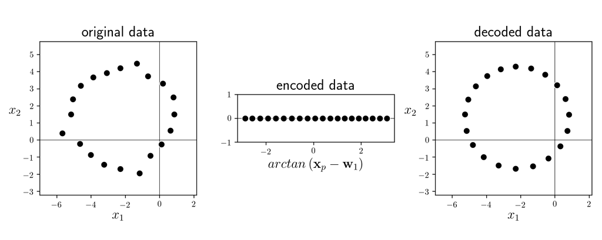

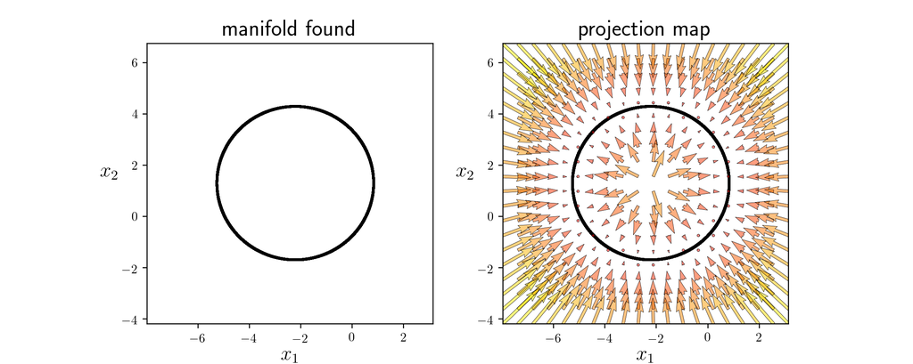

```python
unlib.autoencoder_demos.show_encode_decode(x,encoder,decoder,cost_history_1,weight_history_1,scale = 55,encode_label = r'$\text{arctan}\left(\mathbf{x}_p - \mathbf{w}_1\right)$')
```

#### Example 1. K-means